# Diversity Outbred Micxe

Brian S. Yandell

12/16/2016

This is a study of Diversity Outbred (DO) mice derived from 8 founder strains.

Data: https://github.com/rqtl/qtl2data/  
Reference: Recla JM, Robledo RF, Gatti DM, Bult CJ, Churchill GA, Chesler EJ (2014) Precise genetic mapping and integrative bioinformatics in Diversity Outbred mice reveals Hydin as a novel pain gene. Mamm Genome 25:211-222. [doi:10.1007/s00335-014-9508-0](http://dx.doi.org/10.1007/s00335-014-9508-0) Here are some useful links:

- http://rqtl.org (lots of useful stuff here)
  - A brief tour of R/qtl: [pdf | [code](http://rqtl.org/tutorials/rqtltour.R)]
  - A shorter tour of R/qtl: [pdf | [code](http://rqtl.org/tutorials/rqtltour2.R)]
  - [R/qtl sample data formats](http://rqtl.org/sampledata/)
  - [A Guide to QTL Mapping with R/qtl by Karl W. Broman & Śaunak Sen](http://www.rqtl.org/book/)
- http://kbroman.org/qtl2/
  - See Installation Instructions
  - [R/qtl User Guide](http://kbroman.org/qtl2/assets/vignettes/user_guide.html)
  - [R/qtl2 input file format](http://kbroman.org/qtl2/assets/vignettes/input_files.html)
  - [R/qtl2ggplot](https://github.com/byandell/qtl2ggplot): Yandell version of qtl2plot with grammar of graphics plots ([ggplot2](http://ggplot2.org))

Files for DO mice are in the https://github.com/rqtl/qtl2data/tree/master/DOex. You will need DOex.zip and c2_snpinfo.rds. This is a small subset for teaching purposes of the larger dataset.

## Setup

First we set up needed packages, or libraries.

```r
library(qtl2geno)
library(qtl2scan)
library(qtl2ggplot)
```

Could read in data over the internet. We do it here with local copy, which is downloaded if not found.

```r
do_file <- "DOex.zip"
snp_file <- "c2_snpinfo.rds"
```

Get files from internet if they do not exist locally.

```r
web_address <- file.path("https://raw.githubusercontent.com/rqtl/",
               "qtl2data/master/DOex")
if(!file.exists(do_file)) {
  download.file(file.path(web_address, do_file), do_file, quiet=TRUE)
}
if(!file.exists(snp_file)) {
  download.file(file.path(web_address, snp_file), snp_file, quiet=TRUE)
}
rm(web_address)
```

```r
DOex <- read_cross2(do_file)
```

```r
summary(DOex)
```

```
## Object of class cross2 (crosstype "do")
##
## No. genotyped lines          261
## No. phenotyped individuals   261
##
## No. phenotypes                 1
## No. covariates                 6
## No. phenotype covariates       0
##
## No. chromosomes                3
## Total markers                320
## No. markers by chr:
##   2   3   X
## 125 102  93
```

## Calculate genotype probabilities.

Calculate genotype probabilities. This can take some time and may create a huge file. We reduce to the 8 allele probabilities, which is smaller. We also put the physical map into the probs object. For larger datasets, we save both objects, as they took some time to create.

```r
pr <- calc_genoprob(DOex, error_prob=0.002)
```

Convert to allele probabilities. Switch map to physical map in Mbp.

```r
apr <- genoprob_to_alleleprob(pr)
apr$map <- DOex$pmap
```

```r
pheno_scan <- scan1(apr, DOex$pheno)
```

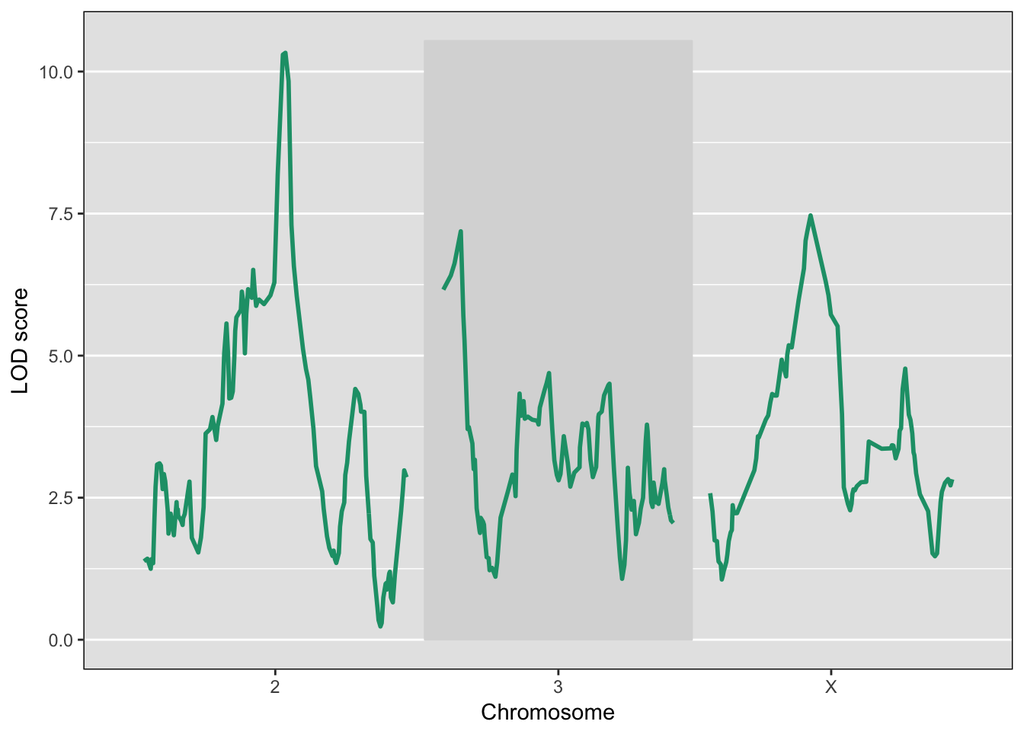

```r
plot(pheno_scan)
```

## QTL scan with kinship adjustment.

Calculate kinship matrices using the `"loco"` option (calculate kinship for each chromosome using SNPs from all but that chromosome).

```r
kinship <- calc_kinship(apr, "loco")
```

Create a copy of the phenotype matrix and rename the phenotype to `"OF_kinship"` for plotting purposes. Do genome scan.

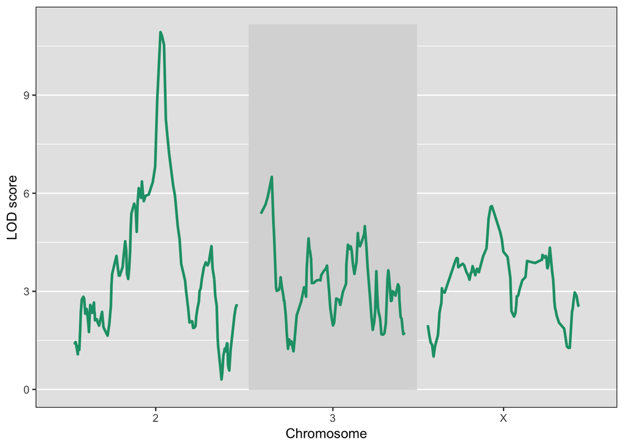

```r
pheno_2 <- DOex$pheno
dimnames(pheno_2)[[2]] <- "OF_kinship"
pheno_scan_2 <- scan1(apr, pheno_2, kinship)
plot(pheno_scan_2)
```

Bind the two scans together and plot.

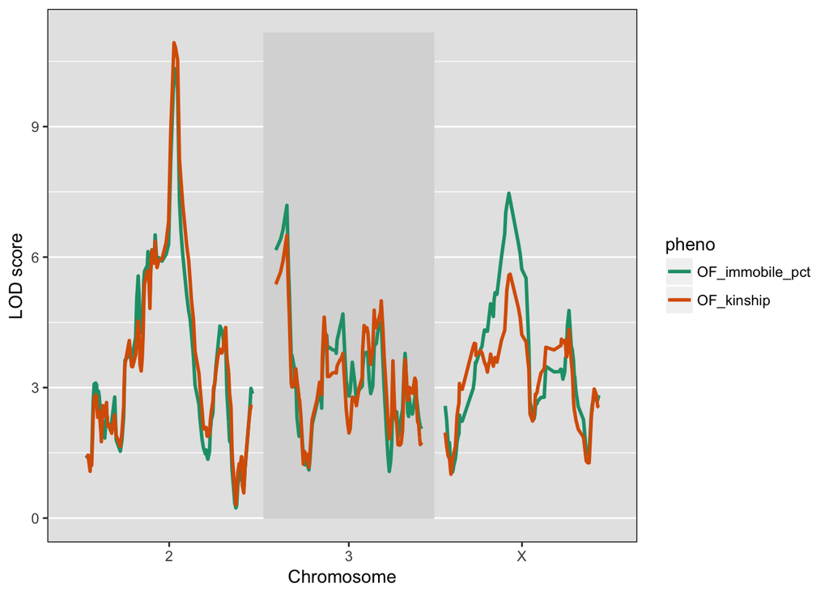

```r
pheno_scan_2 <- cbind(pheno_scan, pheno_scan_2)
plot(pheno_scan_2, 1:2)
```

## Subset to chr 2

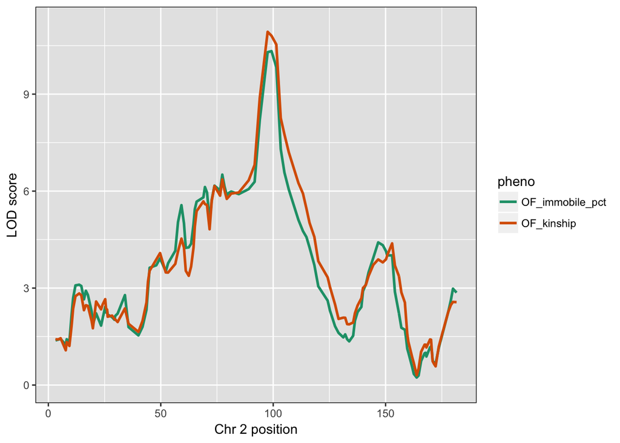

```r
plot(pheno_scan_2, 1:2, chr="2")
```

# Set up SNP info on chr 2.

Read `snpinfo` from file.

```r
snpinfo <- readRDS(snp_file)
```

Calculate strain distribution patterns.

```r
snpinfo$sdp <- calc_sdp(snpinfo[,-(1:4)])
```

Convert to snp probabilities.

```r
snppr <- genoprob_to_snpprob(apr[,"2"], snpinfo)
```

## SNP association analysis

Perform SNP association analysis.

```r
out_snps <- scan1(snppr, DOex$pheno, kinship[["2"]])
```

Plot results

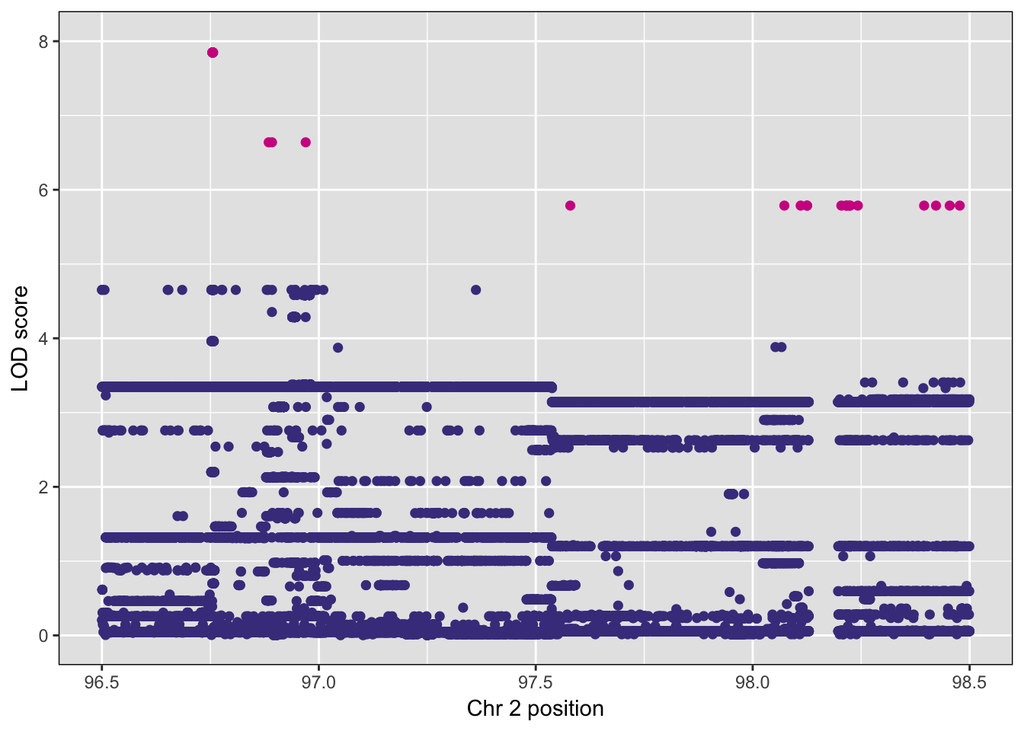

```r
plot(out_snps, cex=2, drop.hilit=2.5)
```

Show strain distribution patterns in SNPs.

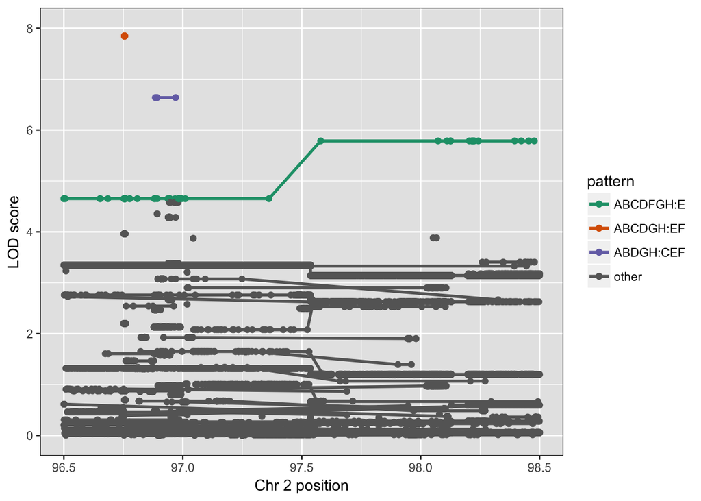

```r
plot(out_snps, patterns="all",drop.hilit=2.5,cex=2)
```

Show only top strain distribution patterns in SNPs.

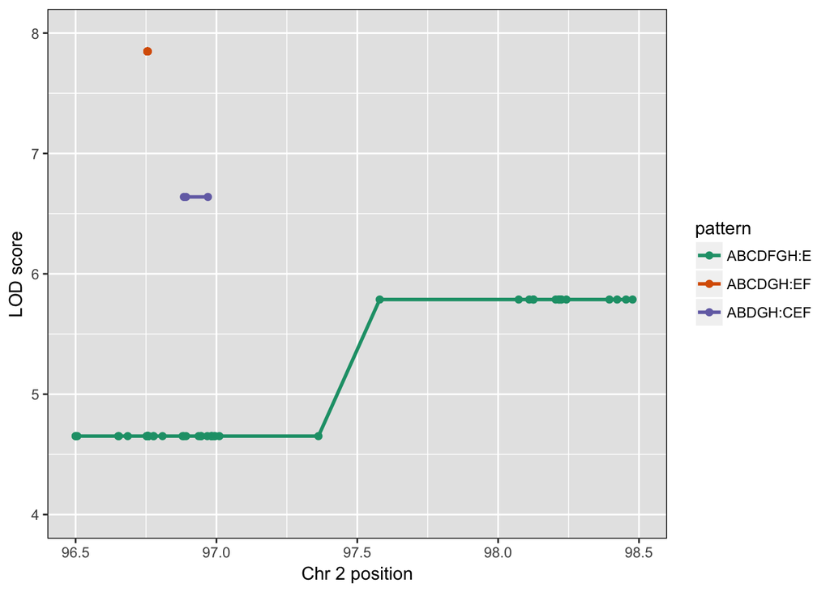

```r
plot(out_snps, patterns="hilit",drop.hilit=2.5,cex=2, ylim=c(4,8))
```